# U.S. Airline Pilot Retention Analysis

General Factor Rankings and Subfactor Priorities

Authors

Affiliations

Michael J. Hickey

University of North Dakota

Marina Efthymiou

Dublin City University

James Higgins

University of North Dakota

Aman Gupta

Embry-Riddle Aeronautical University

Robert Walton

Embry-Riddle Aeronautical University

Published

December 31, 2025

# 1 Overview

**Repository:** [GitHub](https://github.com/mikehickey2/US-Airline-Pilot-Retention-Analysis)

This analysis examines pilot retention priorities from a survey of U.S. airline pilots (n = 76). The analysis has two parts:

1. **General Retention Factors** - Rankings of six broad retention constructs and demographic comparisons
2. **Subfactor Analysis** - Within-construct priorities for 31 specific retention elements

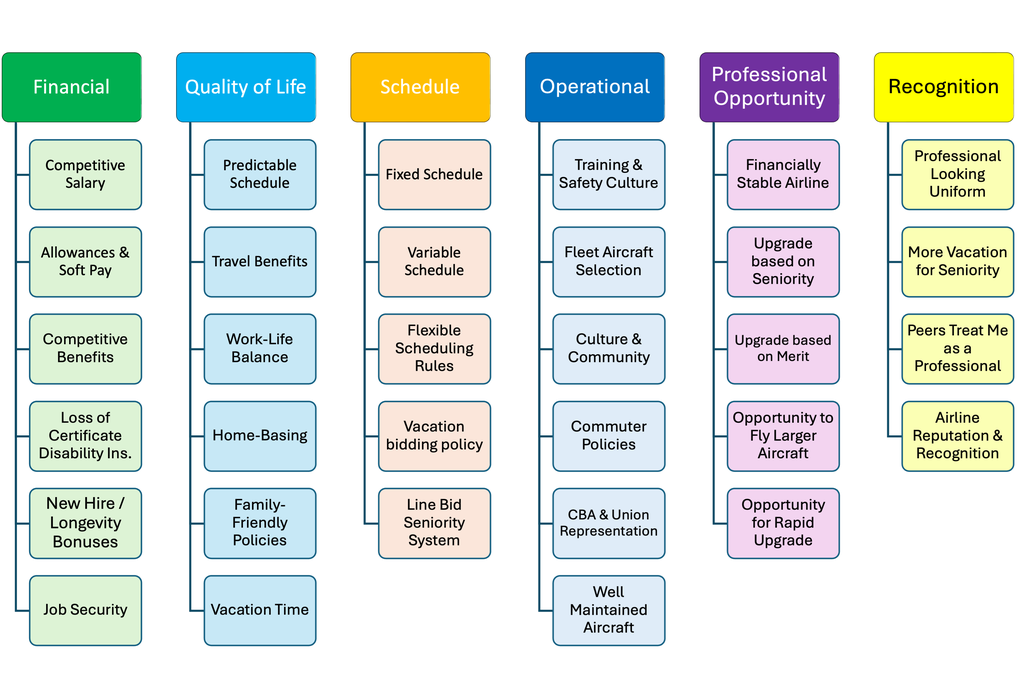

Figure 1: Factors of Pilot Retention in U.S. Airlines

# 2 Statistical Methods

## 2.1 Sample and Data Collection

Survey data was collected from U.S. airline pilots in May 2025. After exclusions for incomplete responses and non-air carrier pilots, n = 76 valid responses remained for analysis.

## 2.2 Statistical Tests

All ranking data is ordinal; therefore, non-parametric tests are used throughout:

- **Friedman Test**: Within-subjects comparison of factor rankings
- **Mann-Whitney U**: Between-groups comparison for binary demographics
- **Kruskal-Wallis H**: Between-groups comparison for multi-level demographics

## 2.3 Multiple Testing Correction

This quantitative study employs a **hierarchical false discovery rate (FDR) control procedure**:

**Subfactor Analysis (155 tests):** Two-step hierarchical procedure:

1. **Screening**: For each construct, compute minimum p-value across demographics. Apply BH-FDR at q = 0.10 to these 6 screening p-values.
2. **Within-construct testing**: For constructs passing screening, apply Holm’s procedure at alpha = 0.05 to demographic comparisons.

**Rationale**: Standard Bonferroni correction (alpha/155 = 0.0003) is overly conservative for exploratory research, causing 50-70% Type II error rates. FDR control at q = 0.10 balances discovery against false positives appropriately for hypothesis generation.

## 2.5 Software

Analysis conducted in R 4.5.1 using: tidyverse, rstatix, coin, DescTools, knitr, janitor.

**Code Availability:** The complete analysis code is available at `scripts/analysis/unified_retention_analysis.qmd` in the [GitHub repository](https://github.com/mikehickey2/US-Airline-Pilot-Retention-Analysis).

# 3 Setup

# 4 Data Loading and Preprocessing

Data Exclusion Summary

| exclusion_reason | n |
| --- | --- |
| did_not_finish | 35 |
| included | 76 |
| not_air_carrier | 2 |

Table 1: Sample Demographic Summary

| Demographic | Category | n |
| --- | --- | --- |
| Age Group | ≤ 35 years | 58 |
|  | > 35 years | 18 |
| Experience | Q1 (least) | 19 |
|  | Q2 | 19 |
|  | Q3 | 19 |
|  | Q4 (most) | 19 |
| Gender | Male | 67 |
|  | Female | 8 |
|  | Other/NA | 1 |
| Military Background | Yes | 7 |
|  | No | 69 |
| Position | Captain | 26 |
|  | First Officer | 50 |
| Carrier Type | Regional | 57 |
|  | Major | 11 |
|  | LCC | 5 |
|  | Other | 3 |

**Final sample:** 76 pilots included in analysis.

# 5 Part 1: General Retention Factor Analysis

This section analyzes the rankings of six broad retention constructs:

1. Financial (salary, benefits, bonuses)
2. Quality of Life/Lifestyle (schedule, family, work-life balance)
3. Professional Opportunity (stability, upgrade, aircraft type)
4. Recognition (uniform, respect, awards)
5. Schedule (fixed vs variable, bidding systems)
6. Operational (SOPs, training, equipment, pilot skill)

## 5.1 Descriptive Statistics

Table 1: Rank Summary for General Retention Factors

| factor | n | median | iqr | mean | sd |
| --- | --- | --- | --- | --- | --- |
| financial | 76 | 2 | 2 | 2.22 | 1.10 |
| lifestyle | 76 | 2 | 2 | 1.99 | 1.16 |
| schedule | 76 | 2 | 1 | 2.46 | 1.01 |
| operational | 76 | 4 | 1 | 4.41 | 1.07 |
| professional | 76 | 5 | 1 | 4.37 | 1.16 |
| recognition | 76 | 6 | 1 | 5.55 | 0.84 |

Table 2: Number (and %) of Pilots Ranking Each Factor #1

| factor | n | percent |
| --- | --- | --- |
| lifestyle | 34 | 44.7 |
| financial | 25 | 32.9 |
| schedule | 13 | 17.1 |
| professional | 3 | 3.9 |
| operational | 1 | 1.3 |

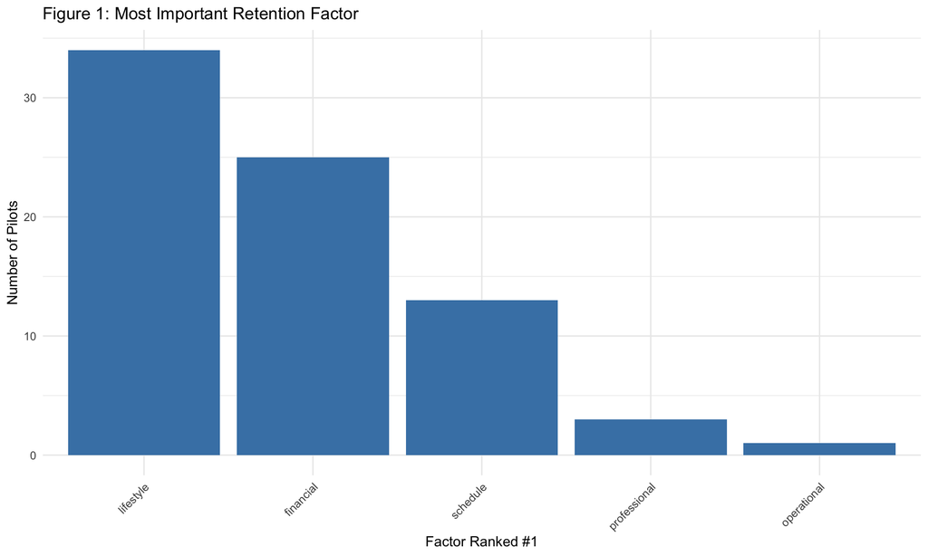

## 5.2 Friedman Test: Overall Factor Rankings

Friedman Test: Overall Difference in Factor Rankings

| .y. | n | statistic | df | p | method |
| --- | --- | --- | --- | --- | --- |
| rank | 76 | 234.316 | 5 | 0 | Friedman test |

Table 3: Pairwise Wilcoxon Tests Between General Factors (Holm-adjusted)

| comparison | statistic | p | p.adj | sig |
| --- | --- | --- | --- | --- |
| financial vs lifestyle | 1700.5 | 0.209 | 0.426 |  |
| financial vs operational | 206.5 | 0.000 | 0.000 | * |
| financial vs professional | 173.0 | 0.000 | 0.000 | * |
| financial vs recognition | 10.5 | 0.000 | 0.000 | * |
| financial vs schedule | 1187.0 | 0.142 | 0.426 |  |
| lifestyle vs operational | 104.0 | 0.000 | 0.000 | * |
| lifestyle vs professional | 149.5 | 0.000 | 0.000 | * |
| lifestyle vs recognition | 45.0 | 0.000 | 0.000 | * |
| lifestyle vs schedule | 1009.0 | 0.016 | 0.062 |  |
| operational vs professional | 1437.0 | 0.892 | 0.892 |  |
| operational vs recognition | 477.0 | 0.000 | 0.000 | * |
| operational vs schedule | 2793.0 | 0.000 | 0.000 | * |
| professional vs recognition | 427.0 | 0.000 | 0.000 | * |
| professional vs schedule | 2667.0 | 0.000 | 0.000 | * |
| recognition vs schedule | 2905.5 | 0.000 | 0.000 | * |

## 5.3 Demographic Comparisons

### 5.3.1 Age Groups (≤35 vs >35)

Table 4: Mann-Whitney U Tests - Age Groups (≤35 vs >35)

| factor | > 35_n | ≤ 35_n | > 35_median | ≤ 35_median | statistic | p_raw | p_adj_fdr | sig_fdr10 | n1 | n2 |
| --- | --- | --- | --- | --- | --- | --- | --- | --- | --- | --- |
| lifestyle | 18 | 58 | 2.5 | 1 | 726.0 | 0.008 | 0.049 | * | 18 | 58 |
| financial | 18 | 58 | 2.0 | 2 | 436.0 | 0.276 | 0.736 |  | 18 | 58 |
| schedule | 18 | 58 | 2.0 | 2 | 466.0 | 0.477 | 0.736 |  | 18 | 58 |
| professional | 18 | 58 | 4.0 | 5 | 479.0 | 0.584 | 0.736 |  | 18 | 58 |
| recognition | 18 | 58 | 6.0 | 6 | 488.5 | 0.613 | 0.736 |  | 18 | 58 |
| operational | 18 | 58 | 4.0 | 4 | 505.0 | 0.832 | 0.832 |  | 18 | 58 |

### 5.3.2 Experience Quartiles

Table 5: Median Rank of General Factors by Experience Quartile

| factor | Q1 (least)_n | Q2_n | Q3_n | Q4 (most)_n | Q1 (least)_median | Q2_median | Q3_median | Q4 (most)_median |
| --- | --- | --- | --- | --- | --- | --- | --- | --- |
| financial | 19 | 19 | 19 | 19 | 2 | 2 | 2 | 2 |
| lifestyle | 19 | 19 | 19 | 19 | 1 | 2 | 2 | 2 |
| operational | 19 | 19 | 19 | 19 | 5 | 4 | 4 | 4 |
| professional | 19 | 19 | 19 | 19 | 4 | 5 | 5 | 5 |
| recognition | 19 | 19 | 19 | 19 | 6 | 6 | 6 | 6 |
| schedule | 19 | 19 | 19 | 19 | 3 | 2 | 2 | 2 |

Table 6: Kruskal-Wallis Tests for Experience Quartiles (FDR-adjusted)

| factor | statistic | df | p_raw | p_adj_fdr | sig_fdr10 |
| --- | --- | --- | --- | --- | --- |
| financial | 0.551 | 3 | 0.908 | 0.908 |  |
| lifestyle | 3.854 | 3 | 0.278 | 0.834 |  |
| operational | 1.364 | 3 | 0.714 | 0.908 |  |
| professional | 1.015 | 3 | 0.798 | 0.908 |  |
| recognition | 4.639 | 3 | 0.200 | 0.834 |  |
| schedule | 2.619 | 3 | 0.454 | 0.908 |  |

### 5.3.3 Gender (Male vs Female)

Table 7: Median Rank of General Factors by Gender

| factor | Female_n | Male_n | Female_median | Male_median |
| --- | --- | --- | --- | --- |
| financial | 8 | 67 | 3 | 2 |
| lifestyle | 8 | 67 | 1 | 2 |
| operational | 8 | 67 | 4 | 5 |
| professional | 8 | 67 | 5 | 5 |
| recognition | 8 | 67 | 6 | 6 |
| schedule | 8 | 67 | 2 | 2 |

Table 8: Mann-Whitney U Tests - Male vs Female (Exact test, FDR-adjusted)

| factor | statistic | p_raw | p_adj_fdr | sig_fdr10 | n1 | n2 |
| --- | --- | --- | --- | --- | --- | --- |
| financial | 365 | 0.084 | 0.168 |  | 8 | 67 |
| lifestyle | 212 | 0.312 | 0.353 |  | 8 | 67 |
| operational | 157 | 0.047 | 0.168 |  | 8 | 67 |
| professional | 320 | 0.353 | 0.353 |  | 8 | 67 |
| recognition | 356 | 0.061 | 0.168 |  | 8 | 67 |
| schedule | 192 | 0.174 | 0.261 |  | 8 | 67 |

**Note**

**Note on Gender Comparisons:** With only 8 female respondents, statistical power for detecting gender differences is limited. Results should be interpreted cautiously.

### 5.3.4 Military Background

Table 9: Median Rank of General Factors by Military Background

| factor | No_n | Yes_n | No_median | Yes_median |
| --- | --- | --- | --- | --- |
| financial | 69 | 7 | 2 | 2 |
| lifestyle | 69 | 7 | 2 | 2 |
| operational | 69 | 7 | 4 | 5 |
| professional | 69 | 7 | 5 | 4 |
| recognition | 69 | 7 | 6 | 6 |
| schedule | 69 | 7 | 2 | 2 |

Table 10: Mann-Whitney U Tests - Military vs Civilian (FDR-adjusted)

| factor | statistic | p_raw | p_adj_fdr | sig_fdr10 | n1 | n2 |
| --- | --- | --- | --- | --- | --- | --- |
| financial | 220.5 | 0.701 | 0.841 |  | 69 | 7 |
| lifestyle | 251.5 | 0.856 | 0.856 |  | 69 | 7 |
| operational | 211.5 | 0.578 | 0.841 |  | 69 | 7 |
| professional | 277.5 | 0.502 | 0.841 |  | 69 | 7 |
| recognition | 198.5 | 0.338 | 0.841 |  | 69 | 7 |
| schedule | 284.5 | 0.423 | 0.841 |  | 69 | 7 |

### 5.3.5 Flight-Deck Position (Captain vs First Officer)

Table 11: Median Rank of General Factors by Flight-Deck Position

| factor | Captain_n | First Officer_n | Captain_median | First Officer_median |
| --- | --- | --- | --- | --- |
| financial | 26 | 50 | 2 | 2 |
| lifestyle | 26 | 50 | 2 | 2 |
| operational | 26 | 50 | 5 | 4 |
| professional | 26 | 50 | 4 | 5 |
| recognition | 26 | 50 | 6 | 6 |
| schedule | 26 | 50 | 2 | 2 |

Table 12: Mann-Whitney U Tests - Captain vs First Officer (FDR-adjusted)

| factor | statistic | p_raw | p_adj_fdr | sig_fdr10 | n1 | n2 |
| --- | --- | --- | --- | --- | --- | --- |
| financial | 489.0 | 0.067 | 0.200 |  | 26 | 50 |
| lifestyle | 723.0 | 0.398 | 0.478 |  | 26 | 50 |
| operational | 865.0 | 0.014 | 0.082 | * | 26 | 50 |
| professional | 543.0 | 0.219 | 0.438 |  | 26 | 50 |
| recognition | 573.5 | 0.296 | 0.444 |  | 26 | 50 |
| schedule | 669.0 | 0.832 | 0.832 |  | 26 | 50 |

### 5.3.6 Carrier Type

Table 13: Median Rank of General Factors by Carrier Type

| factor | LCC_n | Major_n | Other_n | Regional_n | LCC_median | Major_median | Other_median | Regional_median |
| --- | --- | --- | --- | --- | --- | --- | --- | --- |
| financial | 5 | 11 | 3 | 57 | 3 | 2 | 1 | 2 |
| lifestyle | 5 | 11 | 3 | 57 | 2 | 1 | 2 | 2 |
| operational | 5 | 11 | 3 | 57 | 4 | 4 | 4 | 4 |
| professional | 5 | 11 | 3 | 57 | 5 | 5 | 4 | 5 |
| recognition | 5 | 11 | 3 | 57 | 6 | 6 | 6 | 6 |
| schedule | 5 | 11 | 3 | 57 | 1 | 3 | 3 | 2 |

Table 14: Kruskal-Wallis Tests Across Carrier Types (FDR-adjusted)

| factor | statistic | df | p_raw | p_adj_fdr | sig_fdr10 |
| --- | --- | --- | --- | --- | --- |
| financial | 5.451 | 3 | 0.142 | 0.426 |  |
| lifestyle | 1.479 | 3 | 0.687 | 0.687 |  |
| operational | 2.792 | 3 | 0.425 | 0.661 |  |
| professional | 2.304 | 3 | 0.512 | 0.661 |  |
| recognition | 2.102 | 3 | 0.551 | 0.661 |  |
| schedule | 9.233 | 3 | 0.026 | 0.158 |  |

## 5.4 Summary: General Factor Results

Summary: General Factor Demographic Comparisons (BH-FDR at q=0.10)

| Demographic | Tests | Min_p_raw | Min_p_adj | Significant_q10 |
| --- | --- | --- | --- | --- |
| Age (<=35 vs >35) | 6 | 0.0081 | 0.0488 | 1 |
| Experience Quartiles | 6 | 0.2000 | 0.8340 | 0 |
| Gender (Male vs Female) | 6 | 0.0466 | 0.1680 | 0 |
| Military Background | 6 | 0.3380 | 0.8412 | 0 |
| Flight-Deck Position | 6 | 0.0136 | 0.0816 | 1 |
| Carrier Type | 6 | 0.0264 | 0.1584 | 0 |

**General Factor Analysis Summary:**

- Total demographic comparisons: 36
- Significant at FDR q=0.10: 2
- Discovery rate: 5.6%

# 6 Part 2: Subfactor Analysis

This section examines the 31 subfactors within each retention construct and tests for demographic differences in within-construct priorities.

## 6.1 Financial Subfactors

Financial Subfactors - Descriptive Statistics

| item | n | median | mean | sd | pct_rank1 |
| --- | --- | --- | --- | --- | --- |
| Competitive salary | 76 | 2.0 | 1.64 | 0.74 | 47.37 |
| Allowances and soft pay | 76 | 4.0 | 3.96 | 1.24 | 1.32 |
| Benefits package | 76 | 3.0 | 3.36 | 1.14 | 5.26 |
| Disability insurance | 76 | 4.5 | 4.41 | 1.05 | 1.32 |
| Job security | 76 | 2.0 | 2.09 | 1.28 | 44.74 |
| New hire/longevity bonuses | 76 | 6.0 | 5.54 | 0.92 | 0.00 |

Financial: Friedman Test

| .y. | n | statistic | df | p | method |
| --- | --- | --- | --- | --- | --- |
| rank | 76 | 231.06 | 5 | 0 | Friedman test |

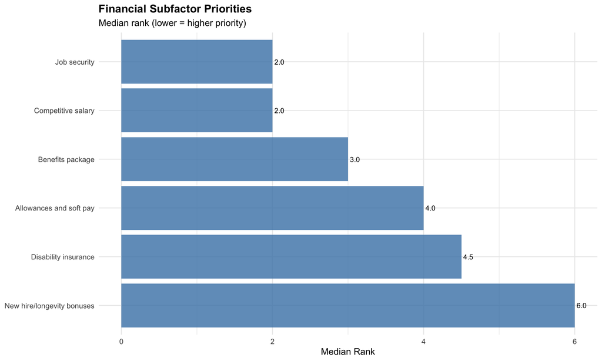

Financial: Age Group Comparisons

| item | statistic | p | p_adj_holm | p.adj.signif | effsize | magnitude |
| --- | --- | --- | --- | --- | --- | --- |
| Competitive salary | 460.5 | 0.406 | 1.000 | ns | 0.096 | small |
| Allowances and soft pay | 502.0 | 0.806 | 1.000 | ns | 0.029 | small |
| Benefits package | 583.0 | 0.444 | 1.000 | ns | 0.088 | small |
| Disability insurance | 515.0 | 0.934 | 1.000 | ns | 0.010 | small |
| Job security | 516.5 | 0.948 | 1.000 | ns | 0.008 | small |
| New hire/longevity bonuses | 619.0 | 0.127 | 0.762 | ns | 0.176 | small |

Financial: Gender Comparisons

| item | statistic | p | p_adj_holm | p.adj.signif | effsize | magnitude |
| --- | --- | --- | --- | --- | --- | --- |
| Competitive salary | 363.0 | 0.069 | 0.415 | ns | 0.211 | small |
| Allowances and soft pay | 332.5 | 0.258 | 1.000 | ns | 0.132 | small |
| Benefits package | 204.0 | 0.259 | 1.000 | ns | 0.131 | small |
| Disability insurance | 174.0 | 0.093 | 0.464 | ns | 0.195 | small |
| Job security | 205.0 | 0.255 | 1.000 | ns | 0.133 | small |
| New hire/longevity bonuses | 311.0 | 0.339 | 1.000 | ns | 0.112 | small |

Financial: Position Comparisons

| item | statistic | p | p_adj_holm | p.adj.signif | effsize | magnitude |
| --- | --- | --- | --- | --- | --- | --- |
| Competitive salary | 603.5 | 0.574 | 1.000 | ns | 0.065 | small |
| Allowances and soft pay | 596.0 | 0.547 | 1.000 | ns | 0.070 | small |
| Benefits package | 646.5 | 0.973 | 1.000 | ns | 0.005 | small |
| Disability insurance | 730.0 | 0.362 | 1.000 | ns | 0.105 | small |
| Job security | 674.5 | 0.781 | 1.000 | ns | 0.033 | small |
| New hire/longevity bonuses | 755.5 | 0.137 | 0.822 | ns | 0.171 | small |

Financial: Military Comparisons

| item | statistic | p | p_adj_holm | p.adj.signif | effsize | magnitude |
| --- | --- | --- | --- | --- | --- | --- |
| Competitive salary | 311.5 | 0.164 | 0.984 | ns | 0.161 | small |
| Allowances and soft pay | 233.5 | 0.890 | 1.000 | ns | 0.017 | small |
| Benefits package | 264.5 | 0.676 | 1.000 | ns | 0.049 | small |
| Disability insurance | 229.0 | 0.821 | 1.000 | ns | 0.027 | small |
| Job security | 169.5 | 0.173 | 0.984 | ns | 0.157 | small |
| New hire/longevity bonuses | 246.0 | 0.926 | 1.000 | ns | 0.012 | small |

Financial: Experience Comparisons

| item | statistic | df | p | p_adj_holm | p.adj.signif | effsize | magnitude |
| --- | --- | --- | --- | --- | --- | --- | --- |
| Competitive salary | 1.885 | 3 | 0.597 | 1 | ns | -0.015 | small |
| Allowances and soft pay | 3.862 | 3 | 0.277 | 1 | ns | 0.012 | small |
| Benefits package | 3.708 | 3 | 0.295 | 1 | ns | 0.010 | small |
| Disability insurance | 4.724 | 3 | 0.193 | 1 | ns | 0.024 | small |
| Job security | 2.263 | 3 | 0.520 | 1 | ns | -0.010 | small |
| New hire/longevity bonuses | 4.884 | 3 | 0.181 | 1 | ns | 0.026 | small |

## 6.2 Quality of Life Subfactors

Quality of Life Subfactors - Descriptive Statistics

| item | n | median | mean | sd | pct_rank1 |
| --- | --- | --- | --- | --- | --- |
| Predictable schedule | 76 | 2 | 2.51 | 1.13 | 19.74 |
| Vacation time | 76 | 4 | 4.12 | 1.18 | 1.32 |
| Family-friendly policies | 76 | 5 | 4.53 | 1.28 | 1.32 |
| Possibility of being based at home | 76 | 2 | 2.70 | 1.87 | 39.47 |
| Travel benefits | 76 | 5 | 4.87 | 1.20 | 1.32 |
| Work-life balance | 76 | 2 | 2.28 | 1.41 | 36.84 |

Quality of Life: Friedman Test

| .y. | n | statistic | df | p | method |
| --- | --- | --- | --- | --- | --- |
| rank | 76 | 139.489 | 5 | 0 | Friedman test |

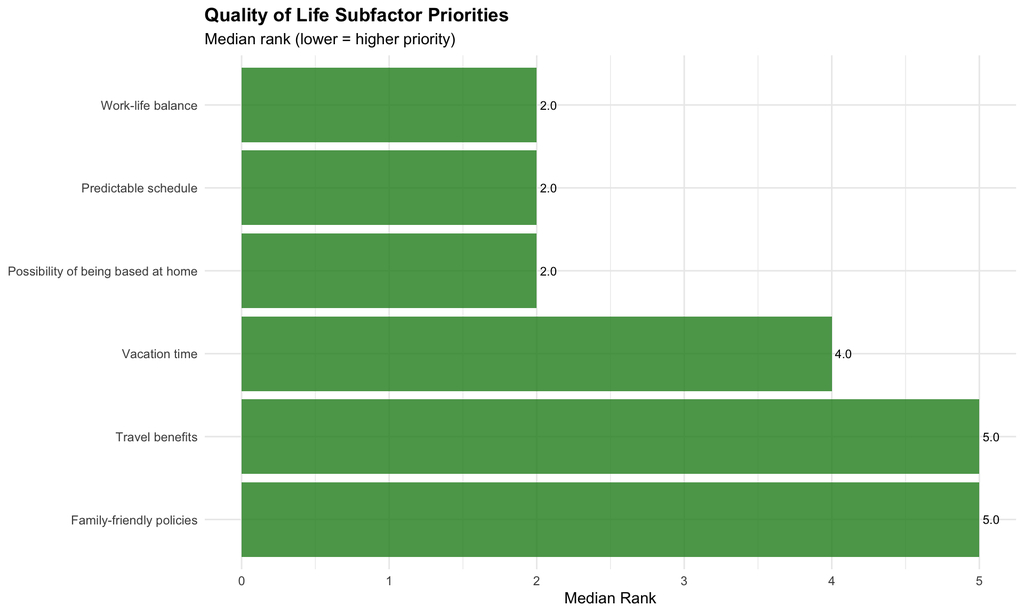

Quality of Life: Age Group Comparisons

| item | statistic | p | p_adj_holm | p.adj.signif | effsize | magnitude |
| --- | --- | --- | --- | --- | --- | --- |
| Predictable schedule | 329.5 | 0.015 | 0.088 | ns | 0.281 | small |
| Vacation time | 544.5 | 0.780 | 1.000 | ns | 0.033 | small |
| Family-friendly policies | 481.0 | 0.610 | 1.000 | ns | 0.059 | small |
| Possibility of being based at home | 529.5 | 0.929 | 1.000 | ns | 0.011 | small |
| Travel benefits | 570.0 | 0.543 | 1.000 | ns | 0.071 | small |
| Work-life balance | 640.0 | 0.134 | 0.670 | ns | 0.173 | small |

Quality of Life: Gender Comparisons

| item | statistic | p | p_adj_holm | p.adj.signif | effsize | magnitude |
| --- | --- | --- | --- | --- | --- | --- |
| Predictable schedule | 197.5 | 0.212 | 1.000 | ns | 0.145 | small |
| Vacation time | 253.5 | 0.803 | 1.000 | ns | 0.030 | small |
| Family-friendly policies | 265.5 | 0.972 | 1.000 | ns | 0.005 | small |
| Possibility of being based at home | 259.0 | 0.880 | 1.000 | ns | 0.019 | small |
| Travel benefits | 359.5 | 0.102 | 0.612 | ns | 0.190 | small |
| Work-life balance | 290.5 | 0.693 | 1.000 | ns | 0.047 | small |

Quality of Life: Position Comparisons

| item | statistic | p | p_adj_holm | p.adj.signif | effsize | magnitude |
| --- | --- | --- | --- | --- | --- | --- |
| Predictable schedule | 722.0 | 0.415 | 1 | ns | 0.094 | small |
| Vacation time | 604.0 | 0.605 | 1 | ns | 0.060 | small |
| Family-friendly policies | 739.5 | 0.315 | 1 | ns | 0.116 | small |
| Possibility of being based at home | 556.0 | 0.287 | 1 | ns | 0.123 | small |
| Travel benefits | 576.5 | 0.402 | 1 | ns | 0.097 | small |
| Work-life balance | 711.5 | 0.485 | 1 | ns | 0.081 | small |

Quality of Life: Military Comparisons

| item | statistic | p | p_adj_holm | p.adj.signif | effsize | magnitude |
| --- | --- | --- | --- | --- | --- | --- |
| Predictable schedule | 193.5 | 0.375 | 1.000 | ns | 0.103 | small |
| Vacation time | 216.0 | 0.641 | 1.000 | ns | 0.055 | small |
| Family-friendly policies | 200.5 | 0.453 | 1.000 | ns | 0.087 | small |
| Possibility of being based at home | 357.5 | 0.031 | 0.186 | ns | 0.249 | small |
| Travel benefits | 236.5 | 0.932 | 1.000 | ns | 0.011 | small |
| Work-life balance | 198.0 | 0.420 | 1.000 | ns | 0.094 | small |

Quality of Life: Experience Comparisons

| item | statistic | df | p | p_adj_holm | p.adj.signif | effsize | magnitude |
| --- | --- | --- | --- | --- | --- | --- | --- |
| Predictable schedule | 7.452 | 3 | 0.059 | 0.353 | ns | 0.062 | moderate |
| Vacation time | 5.189 | 3 | 0.158 | 0.790 | ns | 0.030 | small |
| Family-friendly policies | 4.905 | 3 | 0.179 | 0.790 | ns | 0.026 | small |
| Possibility of being based at home | 2.634 | 3 | 0.451 | 1.000 | ns | -0.005 | small |
| Travel benefits | 1.214 | 3 | 0.750 | 1.000 | ns | -0.025 | small |
| Work-life balance | 1.712 | 3 | 0.634 | 1.000 | ns | -0.018 | small |

## 6.3 Professional Opportunity Subfactors

Professional Subfactors - Descriptive Statistics

| item | n | median | mean | sd | pct_rank1 |
| --- | --- | --- | --- | --- | --- |
| Financially stable airline | 76 | 1 | 1.18 | 0.42 | 82.89 |
| Opportunity for rapid upgrade | 76 | 3 | 3.45 | 1.09 | 1.32 |
| Opportunity to fly larger aircraft | 76 | 3 | 3.26 | 1.43 | 10.53 |
| Promotion/upgrade based on merit | 76 | 3 | 3.45 | 1.24 | 5.26 |
| Upgrade based on length of service | 76 | 4 | 3.66 | 0.97 | 0.00 |

Professional: Friedman Test

| .y. | n | statistic | df | p | method |
| --- | --- | --- | --- | --- | --- |
| rank | 76 | 127.663 | 4 | 0 | Friedman test |

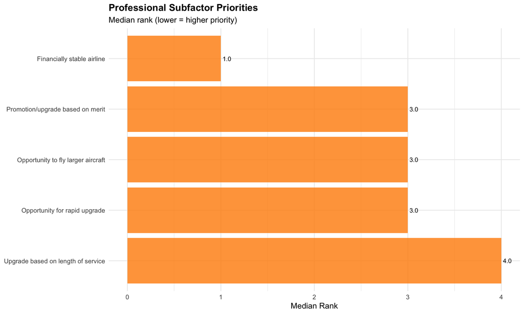

Professional: Age Group Comparisons

| item | statistic | p | p_adj_holm | p.adj.signif | effsize | magnitude |
| --- | --- | --- | --- | --- | --- | --- |
| Financially stable airline | 442.5 | 0.139 | 0.695 | ns | 0.171 | small |
| Opportunity for rapid upgrade | 560.0 | 0.636 | 1.000 | ns | 0.055 | small |
| Opportunity to fly larger aircraft | 558.5 | 0.650 | 1.000 | ns | 0.053 | small |
| Promotion/upgrade based on merit | 495.0 | 0.739 | 1.000 | ns | 0.039 | small |
| Upgrade based on length of service | 498.5 | 0.769 | 1.000 | ns | 0.034 | small |

Professional: Gender Comparisons

| item | statistic | p | p_adj_holm | p.adj.signif | effsize | magnitude |
| --- | --- | --- | --- | --- | --- | --- |
| Financially stable airline | 253.0 | 0.705 | 1.000 | ns | 0.045 | small |
| Opportunity for rapid upgrade | 316.5 | 0.394 | 1.000 | ns | 0.099 | small |
| Opportunity to fly larger aircraft | 355.5 | 0.123 | 0.492 | ns | 0.179 | small |
| Promotion/upgrade based on merit | 173.5 | 0.097 | 0.484 | ns | 0.193 | small |
| Upgrade based on length of service | 216.5 | 0.360 | 1.000 | ns | 0.107 | small |

Professional: Position Comparisons

| item | statistic | p | p_adj_holm | p.adj.signif | effsize | magnitude |
| --- | --- | --- | --- | --- | --- | --- |
| Financially stable airline | 593.5 | 0.348 | 1 | ns | 0.109 | small |
| Opportunity for rapid upgrade | 696.5 | 0.603 | 1 | ns | 0.060 | small |
| Opportunity to fly larger aircraft | 679.5 | 0.743 | 1 | ns | 0.038 | small |
| Promotion/upgrade based on merit | 645.0 | 0.960 | 1 | ns | 0.006 | small |
| Upgrade based on length of service | 578.0 | 0.414 | 1 | ns | 0.094 | small |

Professional: Military Comparisons

| item | statistic | p | p_adj_holm | p.adj.signif | effsize | magnitude |
| --- | --- | --- | --- | --- | --- | --- |
| Financially stable airline | 287.0 | 0.216 | 0.648 | ns | 0.144 | small |
| Opportunity for rapid upgrade | 323.5 | 0.130 | 0.520 | ns | 0.175 | small |
| Opportunity to fly larger aircraft | 135.0 | 0.049 | 0.246 | ns | 0.227 | small |
| Promotion/upgrade based on merit | 229.0 | 0.824 | 0.824 | ns | 0.027 | small |
| Upgrade based on length of service | 303.0 | 0.253 | 0.648 | ns | 0.132 | small |

Professional: Experience Comparisons

| item | statistic | df | p | p_adj_holm | p.adj.signif | effsize | magnitude |
| --- | --- | --- | --- | --- | --- | --- | --- |
| Financially stable airline | 1.667 | 3 | 0.644 | 1.000 | ns | -0.019 | small |
| Opportunity for rapid upgrade | 2.979 | 3 | 0.395 | 1.000 | ns | 0.000 | small |
| Opportunity to fly larger aircraft | 0.302 | 3 | 0.960 | 1.000 | ns | -0.037 | small |
| Promotion/upgrade based on merit | 2.428 | 3 | 0.488 | 1.000 | ns | -0.008 | small |
| Upgrade based on length of service | 6.135 | 3 | 0.105 | 0.525 | ns | 0.044 | small |

## 6.4 Recognition Subfactors

Recognition Subfactors - Descriptive Statistics

| item | n | median | mean | sd | pct_rank1 |
| --- | --- | --- | --- | --- | --- |
| Professional-looking uniforms | 76 | 3 | 2.80 | 0.97 | 14.47 |
| Additional vacation for long service | 76 | 2 | 2.04 | 1.01 | 36.84 |
| Recognition as a professional | 76 | 2 | 1.78 | 0.84 | 44.74 |
| Airline recognition | 76 | 4 | 3.38 | 0.88 | 3.95 |

Recognition: Friedman Test

| .y. | n | statistic | df | p | method |
| --- | --- | --- | --- | --- | --- |
| rank | 76 | 73.168 | 3 | 0 | Friedman test |

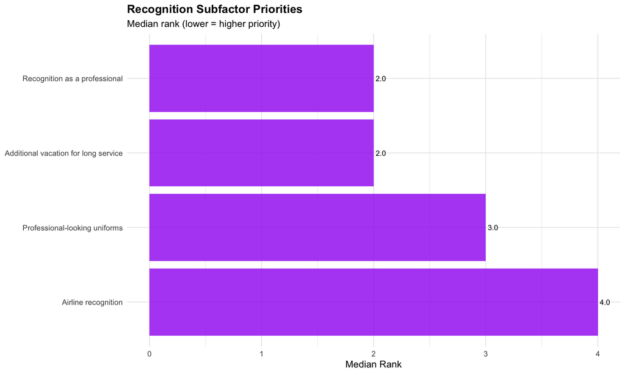

Recognition: Age Group Comparisons

| item | statistic | p | p_adj_holm | p.adj.signif | effsize | magnitude |
| --- | --- | --- | --- | --- | --- | --- |
| Professional-looking uniforms | 577 | 0.476 | 0.900 | ns | 0.082 | small |
| Additional vacation for long service | 345 | 0.023 | 0.093 | ns | 0.261 | small |
| Recognition as a professional | 601 | 0.300 | 0.900 | ns | 0.120 | small |
| Airline recognition | 579 | 0.430 | 0.900 | ns | 0.091 | small |

Recognition: Gender Comparisons

| item | statistic | p | p_adj_holm | p.adj.signif | effsize | magnitude |
| --- | --- | --- | --- | --- | --- | --- |
| Professional-looking uniforms | 183.0 | 0.120 | 0.360 | ns | 0.180 | small |
| Additional vacation for long service | 247.5 | 0.718 | 1.000 | ns | 0.043 | small |
| Recognition as a professional | 264.0 | 0.948 | 1.000 | ns | 0.009 | small |
| Airline recognition | 384.0 | 0.023 | 0.091 | ns | 0.264 | small |

Recognition: Position Comparisons

| item | statistic | p | p_adj_holm | p.adj.signif | effsize | magnitude |
| --- | --- | --- | --- | --- | --- | --- |
| Professional-looking uniforms | 767.5 | 0.171 | 0.513 | ns | 0.158 | small |
| Additional vacation for long service | 496.5 | 0.078 | 0.312 | ns | 0.203 | small |
| Recognition as a professional | 724.0 | 0.385 | 0.770 | ns | 0.100 | small |
| Airline recognition | 618.0 | 0.694 | 0.770 | ns | 0.046 | small |

Recognition: Military Comparisons

| item | statistic | p | p_adj_holm | p.adj.signif | effsize | magnitude |
| --- | --- | --- | --- | --- | --- | --- |
| Professional-looking uniforms | 119.5 | 0.020 | 0.078 | ns | 0.269 | small |
| Additional vacation for long service | 355.5 | 0.032 | 0.096 | ns | 0.247 | small |
| Recognition as a professional | 214.0 | 0.600 | 1.000 | ns | 0.061 | small |
| Airline recognition | 274.0 | 0.511 | 1.000 | ns | 0.077 | small |

Recognition: Experience Comparisons

| item | statistic | df | p | p_adj_holm | p.adj.signif | effsize | magnitude |
| --- | --- | --- | --- | --- | --- | --- | --- |
| Professional-looking uniforms | 4.887 | 3 | 0.180 | 0.540 | ns | 0.026 | small |
| Additional vacation for long service | 8.274 | 3 | 0.041 | 0.163 | ns | 0.073 | moderate |
| Recognition as a professional | 1.184 | 3 | 0.757 | 1.000 | ns | -0.025 | small |
| Airline recognition | 0.637 | 3 | 0.888 | 1.000 | ns | -0.033 | small |

## 6.5 Schedule Subfactors

Schedule Subfactors - Descriptive Statistics

| item | n | median | mean | sd | pct_rank1 |
| --- | --- | --- | --- | --- | --- |
| Fixed schedule | 76 | 3.5 | 3.18 | 1.64 | 25.00 |
| Variable schedule | 76 | 3.0 | 3.39 | 1.39 | 14.47 |
| Flexible work rules | 76 | 2.0 | 2.12 | 1.31 | 42.11 |
| Bid line seniority system | 76 | 3.0 | 2.82 | 1.27 | 18.42 |
| Vacation bidding rules | 76 | 3.0 | 3.49 | 0.97 | 0.00 |

Schedule: Friedman Test

| .y. | n | statistic | df | p | method |
| --- | --- | --- | --- | --- | --- |
| rank | 76 | 37.632 | 4 | 0 | Friedman test |

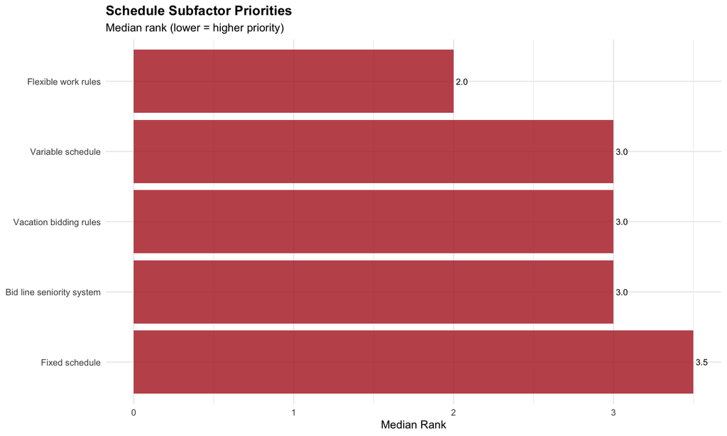

Schedule: Age Group Comparisons

| item | statistic | p | p_adj_holm | p.adj.signif | effsize | magnitude |
| --- | --- | --- | --- | --- | --- | --- |
| Fixed schedule | 464.5 | 0.472 | 1.00 | ns | 0.083 | small |
| Variable schedule | 493.5 | 0.724 | 1.00 | ns | 0.041 | small |
| Flexible work rules | 669.0 | 0.058 | 0.29 | ns | 0.218 | small |
| Bid line seniority system | 574.5 | 0.514 | 1.00 | ns | 0.076 | small |
| Vacation bidding rules | 479.0 | 0.588 | 1.00 | ns | 0.063 | small |

Schedule: Gender Comparisons

| item | statistic | p | p_adj_holm | p.adj.signif | effsize | magnitude |
| --- | --- | --- | --- | --- | --- | --- |
| Fixed schedule | 202.5 | 0.248 | 0.992 | ns | 0.134 | small |
| Variable schedule | 387.0 | 0.036 | 0.180 | ns | 0.243 | small |
| Flexible work rules | 229.5 | 0.489 | 0.992 | ns | 0.081 | small |
| Bid line seniority system | 270.5 | 0.972 | 0.992 | ns | 0.005 | small |
| Vacation bidding rules | 204.0 | 0.256 | 0.992 | ns | 0.132 | small |

Schedule: Position Comparisons

| item | statistic | p | p_adj_holm | p.adj.signif | effsize | magnitude |
| --- | --- | --- | --- | --- | --- | --- |
| Fixed schedule | 606.0 | 0.622 | 1 | ns | 0.057 | small |
| Variable schedule | 647.0 | 0.977 | 1 | ns | 0.004 | small |
| Flexible work rules | 714.0 | 0.462 | 1 | ns | 0.085 | small |
| Bid line seniority system | 747.5 | 0.276 | 1 | ns | 0.126 | small |
| Vacation bidding rules | 551.5 | 0.263 | 1 | ns | 0.129 | small |

Schedule: Military Comparisons

| item | statistic | p | p_adj_holm | p.adj.signif | effsize | magnitude |
| --- | --- | --- | --- | --- | --- | --- |
| Fixed schedule | 177.0 | 0.235 | 1 | ns | 0.137 | small |
| Variable schedule | 286.5 | 0.410 | 1 | ns | 0.096 | small |
| Flexible work rules | 227.5 | 0.797 | 1 | ns | 0.031 | small |
| Bid line seniority system | 216.0 | 0.645 | 1 | ns | 0.054 | small |
| Vacation bidding rules | 257.0 | 0.779 | 1 | ns | 0.033 | small |

Schedule: Experience Comparisons

| item | statistic | df | p | p_adj_holm | p.adj.signif | effsize | magnitude |
| --- | --- | --- | --- | --- | --- | --- | --- |
| Fixed schedule | 1.454 | 3 | 0.693 | 1.000 | ns | -0.021 | small |
| Variable schedule | 0.483 | 3 | 0.923 | 1.000 | ns | -0.035 | small |
| Flexible work rules | 4.079 | 3 | 0.253 | 0.968 | ns | 0.015 | small |
| Bid line seniority system | 4.188 | 3 | 0.242 | 0.968 | ns | 0.016 | small |
| Vacation bidding rules | 5.826 | 3 | 0.120 | 0.600 | ns | 0.039 | small |

## 6.6 Operational Subfactors

Operational Subfactors - Descriptive Statistics

| item | n | median | mean | sd | pct_rank1 |
| --- | --- | --- | --- | --- | --- |
| Unambiguous SOPs | 76 | 3 | 3.07 | 1.59 | 28.95 |
| Proactive training environment | 76 | 3 | 2.84 | 1.17 | 11.84 |
| Well-maintained aircraft | 76 | 2 | 2.25 | 1.16 | 35.53 |
| Well-equipped aircraft | 76 | 5 | 4.13 | 1.18 | 1.32 |
| Highly skilled fellow pilots | 76 | 3 | 2.71 | 1.24 | 22.37 |

Operational: Friedman Test

| .y. | n | statistic | df | p | method |
| --- | --- | --- | --- | --- | --- |
| rank | 76 | 59.463 | 4 | 0 | Friedman test |

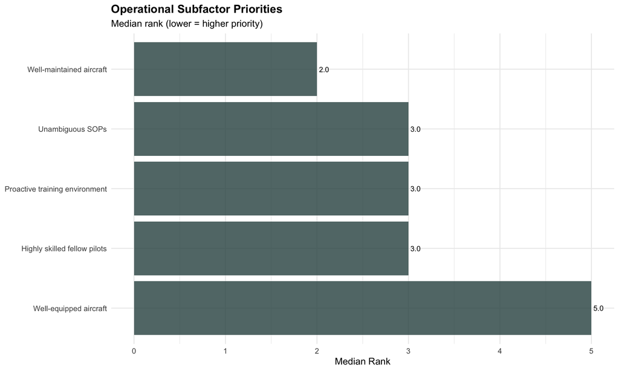

Operational: Age Group Comparisons

| item | statistic | p | p_adj_holm | p.adj.signif | effsize | magnitude |
| --- | --- | --- | --- | --- | --- | --- |
| Unambiguous SOPs | 486.0 | 0.655 | 1.000 | ns | 0.052 | small |
| Proactive training environment | 406.0 | 0.145 | 0.725 | ns | 0.168 | small |
| Well-maintained aircraft | 556.0 | 0.671 | 1.000 | ns | 0.050 | small |
| Well-equipped aircraft | 551.5 | 0.692 | 1.000 | ns | 0.046 | small |
| Highly skilled fellow pilots | 608.0 | 0.283 | 1.000 | ns | 0.124 | small |

Operational: Gender Comparisons

| item | statistic | p | p_adj_holm | p.adj.signif | effsize | magnitude |
| --- | --- | --- | --- | --- | --- | --- |
| Unambiguous SOPs | 255.0 | 0.825 | 1 | ns | 0.027 | small |
| Proactive training environment | 240.0 | 0.626 | 1 | ns | 0.057 | small |
| Well-maintained aircraft | 237.0 | 0.586 | 1 | ns | 0.064 | small |
| Well-equipped aircraft | 328.5 | 0.247 | 1 | ns | 0.135 | small |
| Highly skilled fellow pilots | 290.0 | 0.705 | 1 | ns | 0.045 | small |

Operational: Position Comparisons

| item | statistic | p | p_adj_holm | p.adj.signif | effsize | magnitude |
| --- | --- | --- | --- | --- | --- | --- |
| Unambiguous SOPs | 620.0 | 0.740 | 1 | ns | 0.039 | small |
| Proactive training environment | 722.5 | 0.416 | 1 | ns | 0.094 | small |
| Well-maintained aircraft | 618.0 | 0.720 | 1 | ns | 0.042 | small |
| Well-equipped aircraft | 637.5 | 0.883 | 1 | ns | 0.018 | small |
| Highly skilled fellow pilots | 655.5 | 0.955 | 1 | ns | 0.007 | small |

Operational: Military Comparisons

| item | statistic | p | p_adj_holm | p.adj.signif | effsize | magnitude |
| --- | --- | --- | --- | --- | --- | --- |
| Unambiguous SOPs | 287.0 | 0.405 | 1 | ns | 0.096 | small |
| Proactive training environment | 280.0 | 0.481 | 1 | ns | 0.082 | small |
| Well-maintained aircraft | 218.0 | 0.668 | 1 | ns | 0.050 | small |
| Well-equipped aircraft | 204.5 | 0.463 | 1 | ns | 0.085 | small |
| Highly skilled fellow pilots | 225.0 | 0.768 | 1 | ns | 0.035 | small |

Operational: Experience Comparisons

| item | statistic | df | p | p_adj_holm | p.adj.signif | effsize | magnitude |
| --- | --- | --- | --- | --- | --- | --- | --- |
| Unambiguous SOPs | 4.274 | 3 | 0.233 | 0.932 | ns | 0.018 | small |
| Proactive training environment | 0.476 | 3 | 0.924 | 1.000 | ns | -0.035 | small |
| Well-maintained aircraft | 1.985 | 3 | 0.575 | 1.000 | ns | -0.014 | small |
| Well-equipped aircraft | 0.326 | 3 | 0.955 | 1.000 | ns | -0.037 | small |
| Highly skilled fellow pilots | 5.161 | 3 | 0.160 | 0.800 | ns | 0.030 | small |

## 6.7 Hierarchical FDR Screening Results

Construct-Level Screening: Benjamini-Hochberg FDR (q=0.10)

| construct | n_subfactors | min_p | rank | p_adj_fdr | passes_screen | decision |
| --- | --- | --- | --- | --- | --- | --- |
| Quality of Life | 6 | 0.0147 | 1 | 0.0588 | TRUE | Proceed to detailed testing |
| Recognition | 4 | 0.0196 | 2 | 0.0588 | TRUE | Proceed to detailed testing |
| Schedule | 5 | 0.0359 | 3 | 0.0718 | TRUE | Proceed to detailed testing |
| Professional | 5 | 0.0493 | 4 | 0.0739 | TRUE | Proceed to detailed testing |
| Financial | 6 | 0.0691 | 5 | 0.0829 | TRUE | Proceed to detailed testing |
| Operational | 5 | 0.1450 | 6 | 0.1450 | FALSE | No demographic differences detected |

**Screening Summary:**

- Constructs passing FDR screen (p_adj < 0.10): 5 of 6

**Note**

For constructs passing screening, demographic comparisons have been adjusted using Holm’s procedure. Tests with p_adj_holm < 0.05 indicate significant demographic differences in subfactor prioritization.

# 7 Combined Results Summary

Combined Analysis Summary: Multiple Testing Approach

[output not shown]

## 7.1 Summary

**General Retention Factors (Part 1):**

- Total demographic comparisons: 36
- Significant at FDR q=0.10: 2

**Subfactor Analysis (Part 2):**

**TipInterpretation**

The hierarchical FDR procedure controls for the 155 subfactor tests by:

1. Screening at construct level (BH-FDR q=0.10 on 6 tests)
2. Applying Holm correction within constructs that pass screening

# 8 Limitations

**WarningStatistical Power Considerations**

With n = 76, this study has limited statistical power. Non-significant results should **not** be interpreted as evidence of no effect. Many analyses may be underpowered to detect small-to-medium effects.

This analysis has several important limitations:

## 8.1 Sample Size and Power

The total sample of n = 76 provides adequate power only for detecting large effects (Cohen’s d > 0.8 or r > 0.5). For demographic comparisons:

[output not shown]

**Gender comparisons warrant particular caution**: With only 8 female respondents, the analysis has approximately 20% power to detect medium effects - meaning 80% of true medium-sized gender differences would go undetected.

## 8.2 Additional Limitations

1. **Multiple Testing Burden**: Despite FDR control, the large number of tests (155 in subfactor analysis) increases false discovery risk; the expected number of false discoveries at q=0.10 is approximately 10% of significant findings
2. **Self-Selection Bias**: Survey respondents may not represent all U.S. airline pilots; those with strong opinions about retention may be overrepresented
3. **Cross-Sectional Design**: Retention priorities may change over career stage; this snapshot cannot capture temporal dynamics
4. **Ranking Methodology**: Forced rankings prevent assessment of absolute importance; factors ranked low may still be important in absolute terms

# 9 References

## 9.1 Primary Sources

Hickey, M. J. (2025). *Rethinking pilot retention in the United States: An analysis of key factors* [Master’s thesis, University of North Dakota]. ProQuest Dissertations & Theses. https://www.proquest.com/docview/3246414757

Efthymiou, M., Njoya, E. T., Lo, P. L., Papatheodorou, A., & Randall, D. (2020). The factors influencing entry level airline pilot retention: An empirical study of Ryanair. *Journal of Air Transport Management*, 91, 101997. https://doi.org/10.1016/j.jairtraman.2020.101997

## 9.2 Statistical Methods

Benjamini, Y., & Hochberg, Y. (1995). Controlling the false discovery rate: A practical and powerful approach to multiple testing. *Journal of the Royal Statistical Society: Series B*, 57(1), 289-300.

Bender, R., & Lange, S. (1999). Multiple test procedures other than Bonferroni’s deserve wider use. *BMJ*, 318(7183), 600-601.

Armstrong, R. A. (2014). When to use the Bonferroni correction. *Ophthalmic and Physiological Optics*, 34(5), 502-508.

Li, J., & Ghosh, J. K. (2014). A two-step hierarchical hypothesis set testing framework. *BMC Bioinformatics*, 15, 108.